# Project Case Study 2 Question 5

5.Due to your immense help, your friend startup successfully got seed funding and it is on the operational mode. Now your friend wants to expand his startup and he is looking for new investors for his startup. Now you again come as a saviour to help your friend and want to create a list of probable new new investors. Before moving forward you remember your investor friend advice that finding the investors by analysing the investment type. Since your friend startup is not in early phase it is in growth stage so the best-suited investment type is Private Equity. Find the top 5 investors who have invested in a different number of startups and their investment type is Private Equity. Correct spelling of investment types are - "Private Equity", "Seed Funding", "Debt Funding", and "Crowd Funding". Keep an eye for any spelling mistake. You can find this by printing unique values from this column.There are many errors in startup names. Ignore correcting all, just handle the important ones - Ola, Flipkart, Oyo and Paytm.

```
Sequoia Capital 45
Accel Partners 43
Kalaari Capital 35
Blume Ventures 27
SAIF Partners 24
```

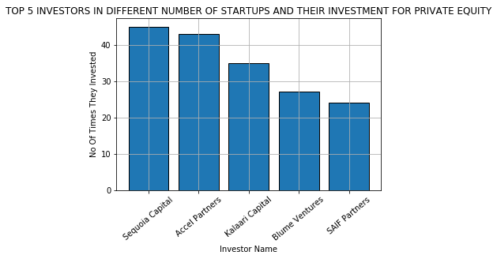

```
'\nThe best-suited investment type is Private Equity, for that i suggest my friend the following investors who have invested in \nPrivate Equity:\n\n1.Sequoia Capital, invested 45 times\n2.Accel Partners, invested 43 times\n3.Kalaari Capital,invested 35 times\n4.Blume Ventures, invested 27 times\n5.…
```

```python
import pandas as pd
import numpy as np
import matplotlib.pyplot as plt
startup = pd.read_csv('C:/Users/sowndariya/Desktop/CNN/startup_funding.csv')
df = startup.copy()
#removing row's having nan's in Investors name and startupnames columns..
df.dropna(subset = ["StartupName","InvestorsName","InvestmentType"],inplace = True)

#ignoring the Undisclosed investors
df= df[df.InvestorsName != 'Undisclosed investors']
df= df[df.InvestorsName != 'Undisclosed Investors']

#replacing the wrong word with the correct one..
df["StartupName"].replace("Flipkart.com","Flipkart",inplace = True)
df["StartupName"].replace("Ola Cabs","Ola",inplace = True)
df["StartupName"].replace("Olacabs","Ola",inplace = True)
df["StartupName"].replace("Oyorooms","Oyo",inplace = True)
df["StartupName"].replace("OyoRooms","Oyo",inplace = True)
df["StartupName"].replace("OYO Rooms","Oyo",inplace = True)
df["StartupName"].replace("Oyo Rooms","Oyo",inplace = True)
df["StartupName"].replace("Paytm Marketplace","Paytm",inplace = True)

df['InvestmentType'].replace("SeedFunding","Seed Funding",inplace=True)
df['InvestmentType'].replace("Crowd funding","Crowd Funding",inplace=True)
df['InvestmentType'].replace("PrivateEquity","Private Equity",inplace=True)

#getting Private Equity Funding
df = df.loc[(df['InvestmentType'] == 'Private Equity')]

#to get seed funding and crowd funding investment type
#firstly ...created a dictionary ...for each investor names ... maintained a set..means each key(investor's name) having a value set(names of stratup's in which they invested)..
#set is taken as a value to avoid count of multiple investment in a single startup by an investor...
#in the set ..there are startup names in which investor's had invested...
#in case there are multiple investors for a single startup...used split function to split that ..and traversed through each name separately...
d = {}
for i in df.index:
    e = df["InvestorsName"][i].strip()
    if "," in e:
        for j in e.strip().split(','):
            if j.strip() in d:
                d[j.strip()].add(df["StartupName"][i].strip())
            else:
                s = set()
                d[j.strip()] = s
                d[j.strip()].add(df["StartupName"][i].strip())
    else:
        a = e.strip()
        if a in d:
            d[a].add(df["StartupName"][i].strip())
        else:
            s = set()
            d[a] = s
            d[a].add(df["StartupName"][i].strip())
#created a dictionary where key is investor's name and value is count of startup's in which they had invested..
d1 = {}
for i in d:
    if i == "":
        continue
    d1[i] = len(d[i])
#sorting the keys according to there values in descending order..and taking the top 5 investor's among all..
investors=[]
counts=[]
for key, value in sorted(d1.items(), key=lambda item: item[1],reverse=True)[0:5]:
    a=key
    investors.append(a)
    b=value
    counts.append(b)
    print(key,value)
#plotting graph
plt.bar(investors,counts,edgecolor='black')
plt.title('TOP 5 INVESTORS IN DIFFERENT NUMBER OF STARTUPS AND THEIR INVESTMENT FOR PRIVATE EQUITY')
plt.xlabel('Investor Name')
plt.ylabel('No Of Times They Invested')
plt.xticks(rotation=40)
plt.grid()
plt.show()

'''
The best-suited investment type is Private Equity, for that i suggest my friend the following investors who have invested in
Private Equity:

1.Sequoia Capital, invested 45 times
2.Accel Partners, invested 43 times
3.Kalaari Capital,invested 35 times
4.Blume Ventures, invested 27 times
5.SAIF Partners, invested 24 times
'''
```